# STAT 5014 HW8

1. I already have a github repository at github.com/sdbookhu/STAT5014Repo

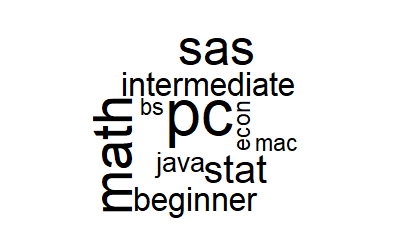

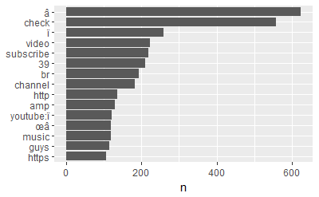

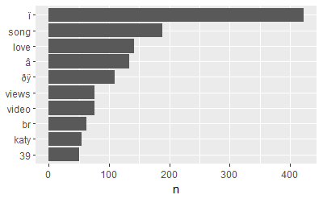

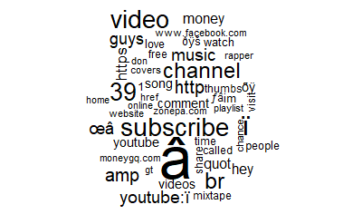

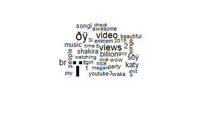

This dataset that I am text-mining is a youtube spam comment collection used for spam research, data obtained from the UCI Machine Learning Repository. There are 5 total video datasets, Psy, Katy Perry, LMFAO, Eminem, and Shakira. There are 5 variables, comment_id (bunch of letters and numbers), youtube author, date of the comment, the comment itself, and a class variable used to determine if a comment is spam or not.

I seperated each set into spam and nonspam comments, then overall gather each set into 2 total sets, one with spam comments, and one with nonspam comments. Then I created bar charts out of each and word clouds out of each.

In the plots above, the first plots are in the spam words, and the second are the nonspam word comments. Overall, it seems spam comments use $\hat{a}$ and i often which I believe are used in links, so spam comments most likely will contain a link in them. Additionally, words like “check”, “video”, and “subscribe” are used next frequently, which means that most often these spam comments are trying to draw attention away from the current video and asking for more views on their channel. In the nonspam comments, the top “word” is i with 2 dots, which again I believe are for links. The next frequent words are song and love, which I believe tells that the nonspam commenters love the video and love the song. Overall, spam commenters are trying to draw attention to their channel and nonspam commenters are just trying to say how much they like the video.

4. I created an ARC account but can’t log on.

## Appendix

```r
# libraries needed for this lab

library(tidyr)
library(tidytext)
library(dplyr)
library(wordcloud)
library(ggplot2)


surveyfile <- read.table("C:/Users/USER/Documents/Fall 2017 Stats/STAT5014/STAT_5014_homework/08_text_mining_Rnotebooks_bash_sed_awk/survey_data.txt",
    sep = "\t", header = T)

# text <- as.vector(surveyfile[,1])

# clean the character string
textdf <- surveyfile

# Mainly the first column

textdf <- apply(textdf, 2, tolower)
textdf <- apply(textdf, 2, function(y) gsub("/", " ", y))
textdf <- apply(textdf, 2, function(y) gsub("math-bs", "math",
    y))
textdf <- apply(textdf, 2, function(y) gsub("finance-bs", "finance",
    y))
textdf <- apply(textdf, 2, function(y) gsub("finance-ms", "",
    y))
textdf <- apply(textdf, 2, function(y) gsub(",", " ", y))
textdf <- apply(textdf, 2, function(y) gsub("math(stat)-bs",
    "math stat", y))

# Second column

textdf <- apply(textdf, 2, function(y) gsub("pc-surface", "pc",
    y))

text <- as.vector(textdf)
text <- trimws(text)
bigtextstr <- strsplit(text, split = " ")

textvec <- unlist(bigtextstr)




text_df <- data_frame(line = 1:length(textvec), text = textvec)


newtextdf <- text_df %>% unnest_tokens(word, text, to_lower = TRUE)

# Time to clean the data

countingwords <- newtextdf %>% count(word, sort = T)

newtextdf %>% anti_join(stop_words) %>% count(word) %>% with(wordcloud(word,
    n))
# 3 case study

# Make up a new case study of my own

# Find my own data?

Psydata <- read.csv("C:/Users/USER/Documents/YouTube-Spam-Collection-v1/Youtube01-Psy.csv")
Katyperrydata <- read.csv("C:/Users/USER/Documents/YouTube-Spam-Collection-v1/Youtube02-KatyPerry.csv")
LMFAOdata <- read.csv("C:/Users/USER/Documents/YouTube-Spam-Collection-v1/Youtube03-LMFAO.csv")
Eminemdata <- read.csv("C:/Users/USER/Documents/YouTube-Spam-Collection-v1/Youtube04-Eminem.csv")
Shakiradata <- read.csv("C:/Users/USER/Documents/YouTube-Spam-Collection-v1/Youtube05-Shakira.csv")

# Convert each dataset into a smaller one with only the
# comment itself

# Seperate into 2 datasets each, one spam, one not spam

spam.psydata <- filter(Psydata, Psydata$CLASS == 1)
nonspam.psydata <- filter(Psydata, Psydata$CLASS == 0)

spam.kpdata <- filter(Katyperrydata, Katyperrydata$CLASS == 1)
nonspam.kpdata <- filter(Katyperrydata, Katyperrydata$CLASS ==
    0)

spam.lmfaodata <- filter(LMFAOdata, LMFAOdata$CLASS == 1)
nonspam.lmfaodata <- filter(LMFAOdata, LMFAOdata$CLASS == 0)

spam.emdata <- filter(Eminemdata, Eminemdata$CLASS == 1)
nonspam.emdata <- filter(Eminemdata, Eminemdata$CLASS == 0)

spam.shadata <- filter(Shakiradata, Shakiradata$CLASS == 1)
nonspam.shadata <- filter(Shakiradata, Shakiradata$CLASS == 0)

# Now convert the content into a character vector

spam.psyvec <- as.vector(spam.psydata[, "CONTENT"])
nonspam.psyvec <- as.vector(nonspam.psydata[, "CONTENT"])

spam.kpvec <- as.vector(spam.kpdata[, "CONTENT"])
nonspam.kpvec <- as.vector(nonspam.kpdata[, "CONTENT"])

spam.lmfaovec <- as.vector(spam.lmfaodata[, "CONTENT"])
nonspam.lmfaovec <- as.vector(nonspam.lmfaodata[, "CONTENT"])

spam.emvec <- as.vector(spam.emdata[, "CONTENT"])
nonspam.emvec <- as.vector(nonspam.emdata[, "CONTENT"])

spam.shavec <- as.vector(spam.shadata[, "CONTENT"])
nonspam.shavec <- as.vector(nonspam.shadata[, "CONTENT"])

# Now convert vector into a dataframe detailing the line and
# text

spam.psytextdf <- data_frame(line = 1:length(spam.psyvec), text = spam.psyvec)
nonspam.psytextdf <- data_frame(line = 1:length(nonspam.psyvec),
    text = nonspam.psyvec)

spam.kptextdf <- data_frame(line = 1:length(spam.kpvec), text = spam.kpvec)
nonspam.kptextdf <- data_frame(line = 1:length(nonspam.kpvec),
    text = nonspam.kpvec)

spam.lmfaotextdf <- data_frame(line = 1:length(spam.lmfaovec),
    text = spam.lmfaovec)
nonspam.lmfaotextdf <- data_frame(line = 1:length(nonspam.lmfaovec),
    text = nonspam.lmfaovec)

spam.emtextdf <- data_frame(line = 1:length(spam.emvec), text = spam.emvec)
nonspam.emtextdf <- data_frame(line = 1:length(nonspam.emvec),
    text = nonspam.emvec)

spam.shatextdf <- data_frame(line = 1:length(spam.shavec), text = spam.shavec)
nonspam.shatextdf <- data_frame(line = 1:length(nonspam.shavec),
    text = nonspam.shavec)

# Now that I have each text df, convert into a longer df with
# only words

spam.ex.psydf <- spam.psytextdf %>% unnest_tokens(word, text) %>%
    anti_join(stop_words)
nonspam.ex.psydf <- nonspam.psytextdf %>% unnest_tokens(word,
    text) %>% anti_join(stop_words)

spam.ex.kpdf <- spam.kptextdf %>% unnest_tokens(word, text) %>%
    anti_join(stop_words)
nonspam.ex.kpdf <- nonspam.kptextdf %>% unnest_tokens(word, text) %>%
    anti_join(stop_words)

spam.ex.lmfaodf <- spam.lmfaotextdf %>% unnest_tokens(word, text) %>%
    anti_join(stop_words)
nonspam.ex.lmfaodf <- nonspam.lmfaotextdf %>% unnest_tokens(word,
    text) %>% anti_join(stop_words)

spam.ex.emdf <- spam.emtextdf %>% unnest_tokens(word, text) %>%
    anti_join(stop_words)
nonspam.ex.emdf <- nonspam.emtextdf %>% unnest_tokens(word, text) %>%
    anti_join(stop_words)

spam.ex.shadf <- spam.shatextdf %>% unnest_tokens(word, text) %>%
    anti_join(stop_words)
nonspam.ex.shadf <- nonspam.shatextdf %>% unnest_tokens(word,
    text) %>% anti_join(stop_words)

# Make a conjoined dataset of all the spam set and all the
# nonspam set

spam.totaldf <- rbind(spam.ex.emdf, spam.ex.kpdf, spam.ex.lmfaodf,
    spam.ex.psydf, spam.ex.shadf)

nonspam.totaldf <- rbind(nonspam.ex.emdf, nonspam.ex.kpdf, nonspam.ex.lmfaodf,
    nonspam.ex.psydf, nonspam.ex.shadf)

# Now time to make visuals out of the words

# spam.ex.psydf %>% count(word, sort = T) %>% filter(n > 15)
# %>% mutate(word =reorder(word, n)) %>% ggplot(aes(word, n))
# + geom_col() + xlab(NULL) + coord_flip()

spam.totaldf %>% count(word, sort = T) %>% filter(n > 100) %>%
    mutate(word = reorder(word, n)) %>% ggplot(aes(word, n)) +
    geom_col() + xlab(NULL) + coord_flip()

nonspam.totaldf %>% count(word, sort = T) %>% filter(n > 50) %>%
    mutate(word = reorder(word, n)) %>% ggplot(aes(word, n)) +
    geom_col() + xlab(NULL) + coord_flip()

# from these analyses, it seems like spam comments include
# check, video, subscribe, 39, br and channel. Br includes
# something from html so it may be easy to see why this is
# spam

# from regular comments, it seems like people love these
# songs

# Now do a word cloud

spam.totaldf %>% count(word) %>% with(wordcloud(word, n, max.words = 50))

nonspam.totaldf %>% count(word) %>% with(wordcloud(word, n, max.words = 50))
```